# Assignment_2: Movie Worldwide Gross Prediction

## Objective: To build a prediction model to forecast the worldwide gross of movies using historical movie datasets.

## Importance:

### Financial Decision-Making: Knowing a movie’s potential worldwide gross helps studios determine their projects' financial viability and make informed production and investment decisions.

### Marketing Budget Allocation: Studios can decide how much to spend on marketing based on expected returns, optimizing spend on promotion.

### Resource Optimization: Gross predictions can better inform key production choices such as visual effects, cast salaries, and international distribution strategies.

### Reducing Risk: Predictive models help to minimize risk by providing studios with revenue expectations, ensuring better decision-making in high-stakes environments.

### Import necessary libraries and load Data

```python
# Import necessary libraries
import pandas as pd
import numpy as np
import matplotlib.pyplot as plt
from sklearn.model_selection import train_test_split
from sklearn.linear_model import LinearRegression
from sklearn.metrics import mean_squared_error
import pandas as pd
import matplotlib.pyplot as plt
import seaborn as sns
import warnings
warnings.filterwarnings("ignore")
from PIL import Image
from google.colab import drive
from sklearn.preprocessing import OneHotEncoder
from sklearn.feature_selection import f_regression
from sklearn.linear_model import Ridge, Lasso, LinearRegression
from sklearn.preprocessing import StandardScaler, PolynomialFeatures
from sklearn.metrics import mean_squared_error, r2_score
from statsmodels.stats.outliers_influence import variance_inflation_factor
from sklearn.preprocessing import StandardScaler
from sklearn.linear_model import Lasso
import plotly.graph_objs as go
from plotly.subplots import make_subplots
```

### Import Dataset

```python
# Mount Google Drive
drive.mount('/content/drive')
```

```python
# Read a file from Google Drive
file_path = '/content/drive/My Drive/Assignment2/Most_Profitable_Movies_of_All_Time _Top 500 Movies.csv'  # Replace with your file's path
```

```python
df = pd.read_csv(file_path)
```

### Look at the contents of the dataframe

```python
# Display 3 random rows from the DataFrame
df.sample(4)
```

|  | title | worldwide gross (m) | % budget recovered | X times budget recovered | budget (millions) | domestic gross (m) | domestic % | international gross (m) | % of gross from international | worldwide gross | year | decade | source | budget source | force label | horror |
| --- | --- | --- | --- | --- | --- | --- | --- | --- | --- | --- | --- | --- | --- | --- | --- | --- |
| 457 | The Last Samurai | 455.0 | 325% | 3.2 | 140.0 | 111.0 | 24.4% | 344.0 | 75.6% | 454627263 | 2003 | 2000's | https://www.boxofficemojo.com/chart/ww_top_lif... | https://en.wikipedia.org/wiki/The_Last_Samurai | NaN | not horror |
| 224 | Knives Out | 313.0 | 782% | 7.8 | 40.0 | 165.0 | 52.8% | 148.0 | 47.2% | 312897920 | 2019 | 2010's | https://www.boxofficemojo.com/chart/ww_top_lif... | https://en.wikipedia.org/wiki/Knives_Out | NaN | not horror |
| 394 | Terminator 2 | 521.0 | 521% | 5.2 | 100.0 | 206.0 | 39.5% | 315.0 | 60.5% | 520881154 | 1991 | 1990's | https://www.boxofficemojo.com/chart/ww_top_lif... | https://en.wikipedia.org/wiki/Terminator_2:_Ju... | NaN | not horror |
| 329 | Ready Player One | 583.0 | 333% | 3.3 | 175.0 | 138.0 | 23.6% | 445.0 | 76.4% | 582918849 | 2018 | 2010's | https://www.boxofficemojo.com/chart/ww_top_lif... | https://en.wikipedia.org/wiki/Ready_Player_One... | NaN | not horror |

```python
df.shape # Displayed rows and columns
```

```
(562, 16)
```

```python
print(df.dtypes)
```

```
title                             object
worldwide gross (m)              float64
% budget recovered                object
X times budget recovered         float64
budget  (millions)               float64
domestic gross (m)               float64
domestic %                        object
international gross (m)          float64
% of gross from international     object
worldwide gross                    int64
year                               int64
decade                            object
source                            object
budget source                     object
force label                       object
horror                            object
dtype: object
```

# 1. Column adjustments with an underscore

```python
# Replace spaces with underscores in column names
df.columns = [col.strip().replace(' ', '_').replace('/', '_') for col in df.columns]

print("\nUpdated column names:")
print(df.columns)
```

```
Updated column names:
Index(['title', 'worldwide_gross_(m)', '%_budget_recovered',
       'X_times_budget_recovered', 'budget__(millions)', 'domestic_gross_(m)',
       'domestic_%', 'international_gross_(m)',
       '%_of_gross_from_international', 'worldwide_gross', 'year', 'decade',
       'source', 'budget_source', 'force_label', 'horror'],
      dtype='object')
```

# 2. Drop all columns as they have free-flowing text, and we are doing work on tabular data

```python
df = df.drop(columns=['source' , 'budget_source', 'force_label', 'title' ])# drops all missing values in the data
```

```python
print(df.isnull().sum())
```

```
worldwide_gross_(m)              0
%_budget_recovered               0
X_times_budget_recovered         0
budget__(millions)               0
domestic_gross_(m)               0
domestic_%                       0
international_gross_(m)          0
%_of_gross_from_international    0
worldwide_gross                  0
year                             0
decade                           0
horror                           0
dtype: int64
```

```python
print(df.isnull().values.any())
```

```
False
```

# 3. Convert all the percentage columns to float numbers

```python
# Convert the percentage columns by removing the '%' and converting to float
df['%_budget_recovered'] = df['%_budget_recovered'].str.rstrip('%').astype(float)
df['domestic_%'] = df['domestic_%'].str.rstrip('%').astype(float)
df['%_of_gross_from_international'] = df['%_of_gross_from_international'].str.rstrip('%').astype(float)

# Check the updated DataFrame
print(df[['%_budget_recovered', 'domestic_%', '%_of_gross_from_international']].head())
```

```
   %_budget_recovered  domestic_%  %_of_gross_from_international
0               702.0        46.2                           53.8
1               427.0        41.4                           58.6
2               396.0        21.0                           79.0
3               479.0        42.5                           57.5
4               663.0        57.9                           42.1
```

# Finding correlation of missing value

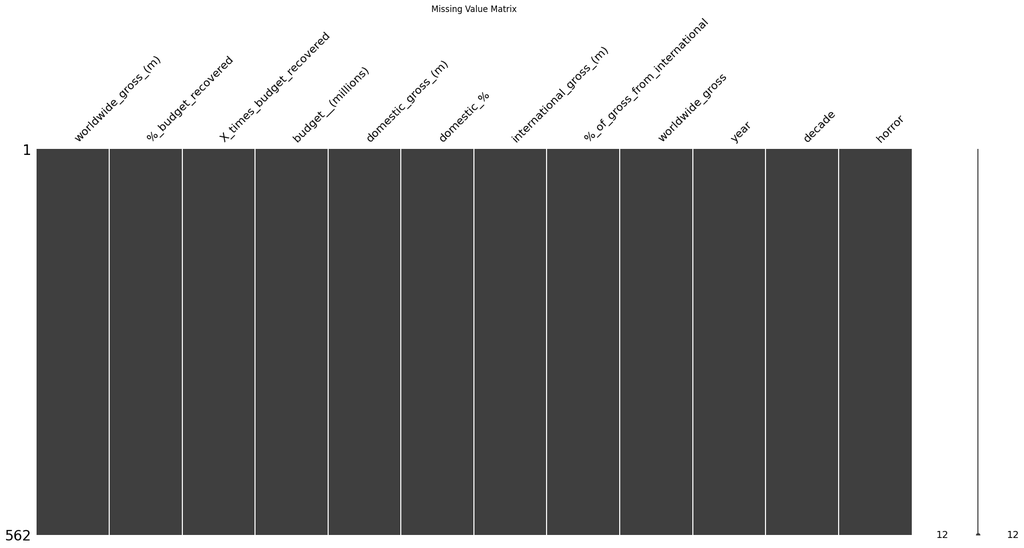

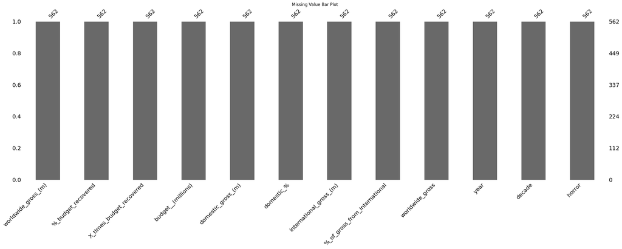

[figure not shown]

```
worldwide_gross_(m)              0.0
%_budget_recovered               0.0
X_times_budget_recovered         0.0
budget__(millions)               0.0
domestic_gross_(m)               0.0
domestic_%                       0.0
international_gross_(m)          0.0
%_of_gross_from_international    0.0
worldwide_gross                  0.0
year                             0.0
decade                           0.0
horror                           0.0
dtype: float64
```

```python
import pandas as pd
import matplotlib.pyplot as plt
import seaborn as sns
import missingno as msno


# Visualize missing values using missingno
plt.figure(figsize=(12, 6))
msno.matrix(df)
plt.title('Missing Value Matrix')
plt.tight_layout()
plt.show()

# Bar plot of missing values
plt.figure(figsize=(12, 6))
msno.bar(df)
plt.title('Missing Value Bar Plot')
plt.tight_layout()
plt.show()

# Correlation of missingness
plt.figure(figsize=(12, 10))
msno.heatmap(df)
plt.title('Correlation of Missingness')
plt.tight_layout()
plt.show()

# Print percentage of missing values
missing_percentages = df.isnull().mean() * 100
print(missing_percentages.sort_values(ascending=False))
```

```python
print(df.isnull().sum())
```

```
worldwide_gross_(m)              0
%_budget_recovered               0
X_times_budget_recovered         0
budget__(millions)               0
domestic_gross_(m)               0
domestic_%                       0
international_gross_(m)          0
%_of_gross_from_international    0
worldwide_gross                  0
year                             0
decade                           0
horror                           0
dtype: int64
```

# 4. Break out numerical and categorical columns

```python
numerical_columns = df.select_dtypes(include=['number'])
```

```python
categorical_columns = df.select_dtypes(include=['object', 'category'])
```

```python
print("Numerical columns:", numerical_columns.columns)
print("Categorical columns:", categorical_columns.columns)
```

```
Numerical columns: Index(['worldwide_gross_(m)', '%_budget_recovered', 'X_times_budget_recovered',
       'budget__(millions)', 'domestic_gross_(m)', 'domestic_%',
       'international_gross_(m)', '%_of_gross_from_international',
       'worldwide_gross', 'year'],
      dtype='object')
Categorical columns: Index(['decade', 'horror'], dtype='object')
```

# 5. Create the histogram plot Worldwide Gross (This is your target or dependent variable that you are trying to predict) – bins=50 and kde=true

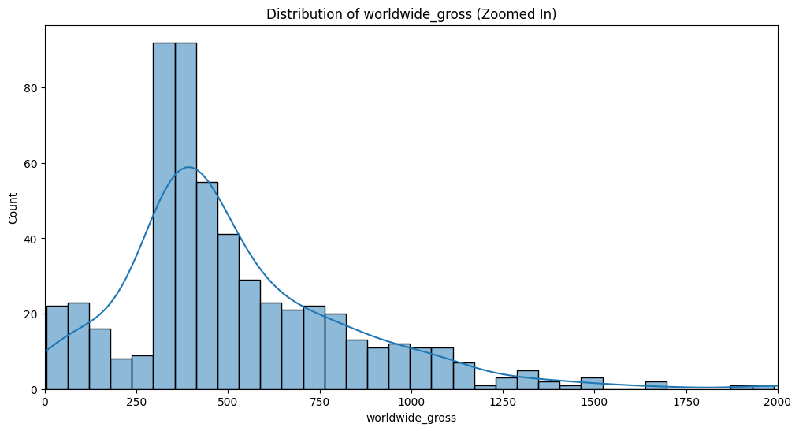

```python
import matplotlib.pyplot as plt
import seaborn as sns

# Assuming the data for 'worldwide_gross' is in a dataframe called df
plt.figure(figsize=(12, 6))
sns.histplot(df['worldwide_gross_(m)'], bins=50, kde=True)
plt.xlim(0, 2000)  # Adjust the x-axis limits to zoom in on lower MSRP values (e.g., up to 100,000)
plt.title('Distribution of worldwide_gross (Zoomed In)')
plt.xlabel( 'worldwide_gross')
plt.ylabel('Count')
plt.show()
```

# 6. Univariate EDA on numerical variables - Create histogram plots for budget, domestic gross, international gross, and X time budget recovered

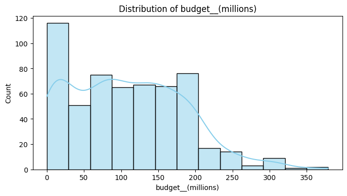

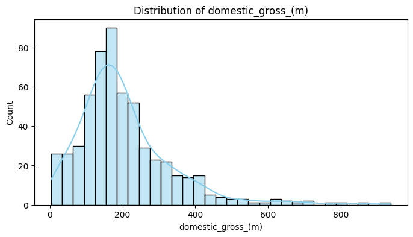

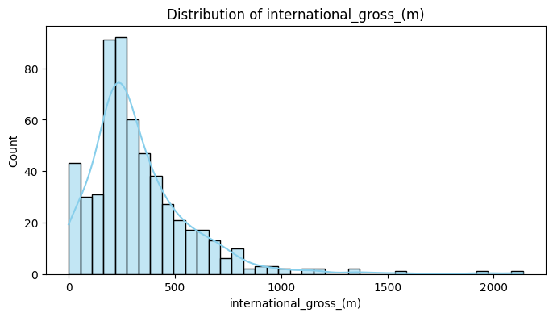

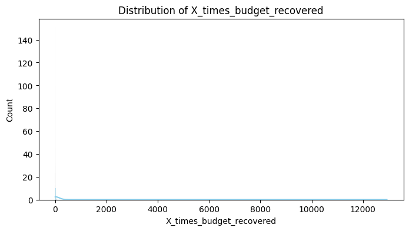

```python
import seaborn as sns
import matplotlib.pyplot as plt

numerical_columns = ['budget__(millions)', 'domestic_gross_(m)', 'international_gross_(m)', 'X_times_budget_recovered']
# Plot histograms for each numerical column with a specific color
for column in numerical_columns:
    plt.figure(figsize=(8, 4))
    sns.histplot(df[column], kde=True, color='skyblue')  # Change color to 'skyblue'
    plt.title(f'Distribution of {column}')
    plt.show()
```

# 7. Univariate EDA on numerical variables - Create a scatter plot for Worldwide Gross vs. Budget (Millions), Worldwide Gross vs. Domestic Gross (in Millions)', Worldwide Gross vs. Domestic %, Worldwide Gross vs. International Gross (in Millions), Worldwide Gross vs. % of Gross from International

```python
# Select and print all numerical columns
numerical_columns = df.select_dtypes(include=['number']).columns
print("Numerical variables in the DataFrame:")
for col in numerical_columns:
    print(col)
```

```
Numerical variables in the DataFrame:
worldwide_gross_(m)
%_budget_recovered
X_times_budget_recovered
budget__(millions)
domestic_gross_(m)
domestic_%
international_gross_(m)
%_of_gross_from_international
worldwide_gross
year
```

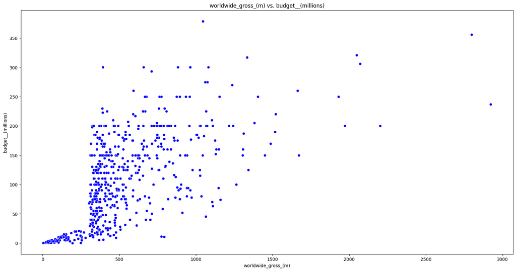

```python
plt.figure(figsize=(20,10))
sns.scatterplot(data = df , x ="worldwide_gross_(m)" ,  y = "budget__(millions)" , color = "blue")
plt.title('worldwide_gross_(m) vs. budget__(millions)')
plt.xlabel('worldwide_gross_(m)')
plt.ylabel('budget__(millions)')
plt.show()
```

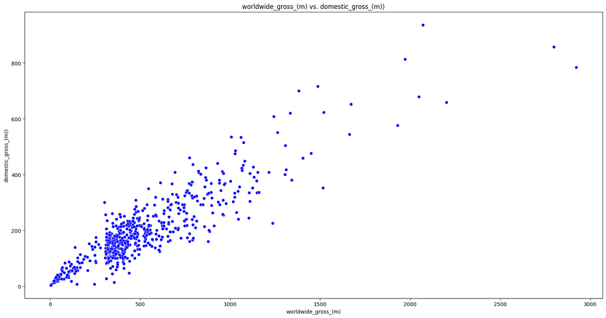

```python
plt.figure(figsize=(20,10))
sns.scatterplot(data = df , x ="worldwide_gross_(m)" ,  y = "domestic_gross_(m)" , color = "blue")
plt.title('worldwide_gross_(m) vs. domestic_gross_(m))')
plt.xlabel('worldwide_gross_(m)')
plt.ylabel('domestic_gross_(m))')
plt.show()
```

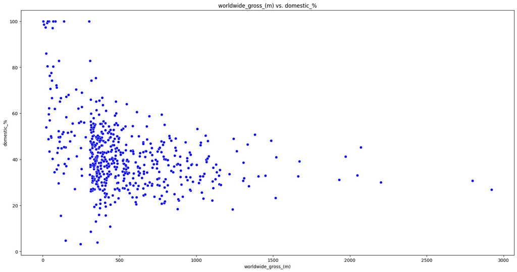

```python
plt.figure(figsize=(20,10))
sns.scatterplot(data = df , x ="worldwide_gross_(m)" ,  y = "domestic_%" , color = "blue")
plt.title('worldwide_gross_(m) vs. domestic_%')
plt.xlabel('worldwide_gross_(m)')
plt.ylabel('domestic_%')
plt.show()
```

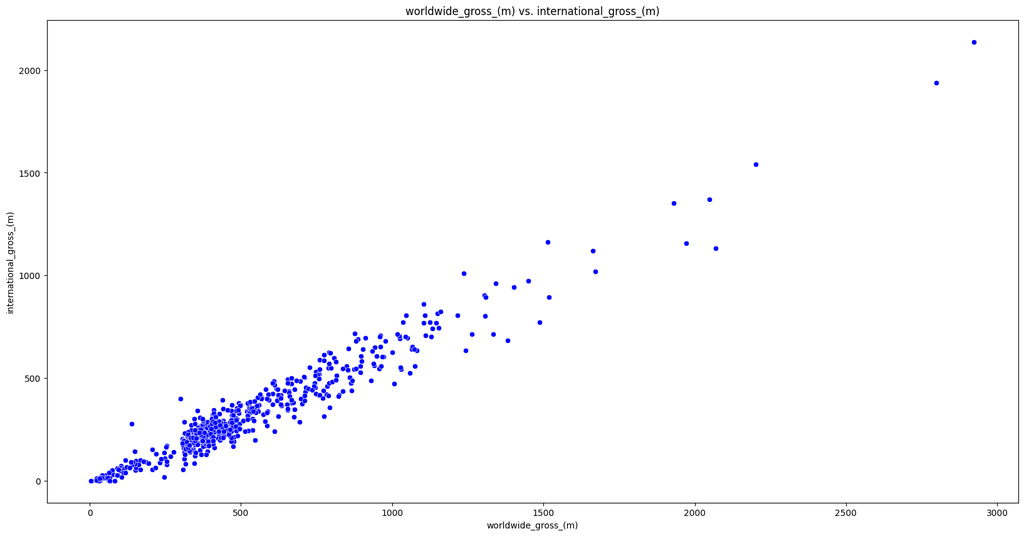

```python
plt.figure(figsize=(20,10))
sns.scatterplot(data = df , x ="worldwide_gross_(m)" ,  y = "international_gross_(m)" , color = "blue")
plt.title('worldwide_gross_(m) vs. international_gross_(m)')
plt.xlabel('worldwide_gross_(m)')
plt.ylabel('international_gross_(m)')
plt.show()
```

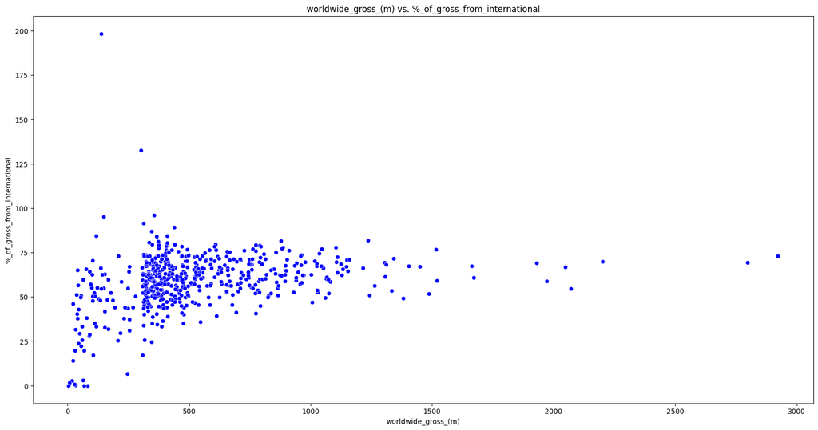

```python
plt.figure(figsize=(20,10))
sns.scatterplot(data = df , x ="worldwide_gross_(m)" ,  y = "%_of_gross_from_international" , color = "blue")
plt.title('worldwide_gross_(m) vs. %_of_gross_from_international')
plt.xlabel('worldwide_gross_(m)')
plt.ylabel('%_of_gross_from_international')
plt.show()
```

# 8. Univariate EDA on categorical variables –Count plots

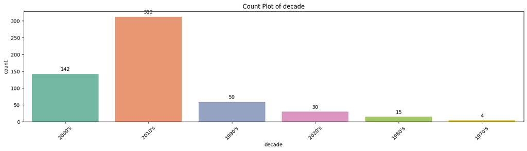

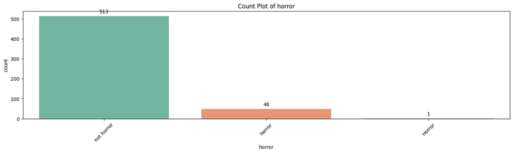

```python
# Plot count plots for each categorical column with a custom palette and annotations
for column in categorical_columns:
    plt.figure(figsize=(18, 4))
    ax = sns.countplot(data=df, x=column, palette='Set2')  # Change palette to 'Set2'

    # Add count annotations on top of the bars
    for p in ax.patches:
        ax.annotate(f'{p.get_height():.0f}',
                    (p.get_x() + p.get_width() / 2., p.get_height()),
                    ha='center', va='center',
                    xytext=(0, 9),  # Adjust the position of the text
                    textcoords='offset points')

    plt.title(f'Count Plot of {column}')
    plt.xticks(rotation=45)
    plt.show()
```

# 9. Bi-variate EDA – Worldwide Gross vs. Decade hue=Horror (e.g. Of plot provided below)

```python
# Manually specify one numerical variable and one categorical variable
numerical_column = 'worldwide_gross_(m)'  # Replace with your chosen numerical column
categorical_column = 'decade'  # Replace with your chosen categorical column
hue_column = 'horror'  # Replace with your chosen hue column, or set it to None if not needed

print(f"Numerical column: {numerical_column}")
print(f"Categorical column: {categorical_column}")
print(f"Hue column: {hue_column}")
```

```
Numerical column: worldwide_gross_(m)
Categorical column: decade
Hue column: horror
```

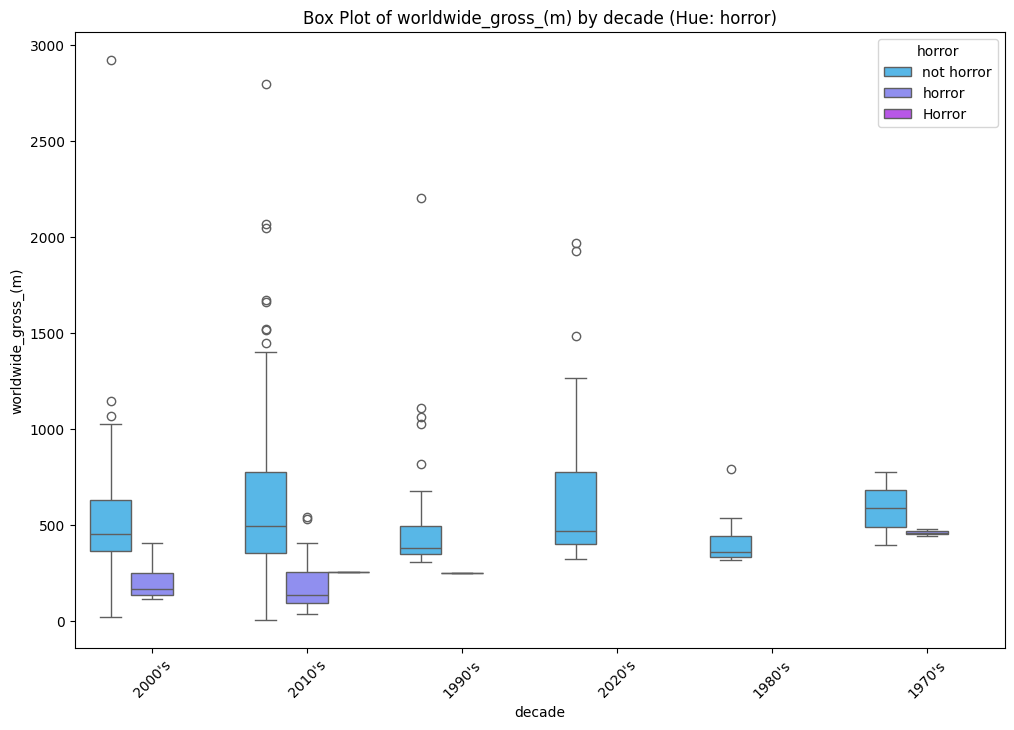

```python
import matplotlib.pyplot as plt  # Add this import
import seaborn as sns  # This was likely already imported since sns is working

# Box plot for numerical vs categorical variable (with optional hue)
plt.figure(figsize=(12, 8))
sns.boxplot(x=categorical_column, y=numerical_column, hue=hue_column, data=df, palette='cool')
plt.title(f'Box Plot of {numerical_column} by {categorical_column} (Hue: {hue_column})')
plt.xticks(rotation=45)
plt.show()
```

# 10. Bi-variate EDA – International Gross vs. Decade hue=Horror

```python
# Manually specify one numerical variable and one categorical variable
numerical_column = 'international_gross_(m)'  # Replace with your chosen numerical column
categorical_column = 'decade'  # Replace with your chosen categorical column
hue_column = 'horror'  # Replace with your chosen hue column, or set it to None if not needed

print(f"Numerical column: {numerical_column}")
print(f"Categorical column: {categorical_column}")
print(f"Hue column: {hue_column}")
```

```
Numerical column: international_gross_(m)
Categorical column: decade
Hue column: horror
```

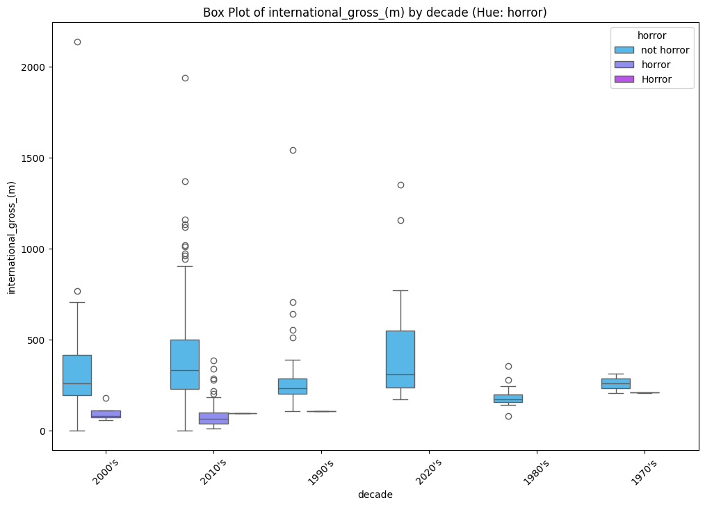

```python
import matplotlib.pyplot as plt  # Add this import
import seaborn as sns  # This was likely already imported since sns is working

# Box plot for numerical vs categorical variable (with optional hue)
plt.figure(figsize=(12, 8))
sns.boxplot(x=categorical_column, y=numerical_column, hue=hue_column, data=df, palette='cool')
plt.title(f'Box Plot of {numerical_column} by {categorical_column} (Hue: {hue_column})')
plt.xticks(rotation=45)
plt.show()
```

# 11. Encode your two categorical variables, decade and horror, using one-hot encoding using the pd.get_dummies function. ( In lecture 4 we covered one-hot encoding)

```python
#import pandas as pd

# One-hot encode the categorical variables 'decade' and 'horror'
df_encoded = pd.get_dummies(df, columns=['decade', 'horror'], drop_first=True)

# Check the DataFrame after encoding
df_encoded.sample(3)
```

|  | worldwide_gross_(m) | %_budget_recovered | X_times_budget_recovered | budget__(millions) | domestic_gross_(m) | domestic_% | international_gross_(m) | %_of_gross_from_international | worldwide_gross | year | decade_1980's | decade_1990's | decade_2000's | decade_2010's | decade_2020's | horror_horror | horror_not horror |
| --- | --- | --- | --- | --- | --- | --- | --- | --- | --- | --- | --- | --- | --- | --- | --- | --- | --- |
| 11 | 436.0 | 1212.0 | 12.1 | 36.0 | 215.0 | 49.4 | 221.0 | 50.6 | 436233122 | 2018 | False | False | False | True | False | False | True |
| 183 | 877.0 | 923.0 | 9.2 | 95.0 | 161.0 | 18.4 | 716.0 | 81.6 | 877244782 | 2012 | False | False | False | True | False | False | True |
| 498 | 91.0 | 1819.0 | 18.2 | 5.0 | 64.7 | 71.2 | 26.2 | 28.8 | 90937439 | 2015 | False | False | False | True | False | True | False |

# 12. Prepare data set for machine learning - Split the data into train (60%), validation (20%), and test (20%) sets – note your depended variable or the variable you are trying to predict isworldwide_gross in millions

# 13. Print the sizes of the dataset

```python
from sklearn.model_selection import train_test_split

# Define the independent (X) and dependent (Y) variables
X = df_encoded.drop(columns=['worldwide_gross_(m)'])  # Drop the dependent variable from features
y = df_encoded['worldwide_gross_(m)']  # Define the target variable

# Split the data into train (60%), validation (20%), and test (20%) sets
X_train, X_temp, y_train, y_temp = train_test_split(X, y, test_size=0.4, random_state=42)
X_validate, X_test, y_validate, y_test = train_test_split(X_temp, y_temp, test_size=0.5, random_state=42)

# Print the sizes of the datasets
print(f"Sizes of datasets - Train: {X_train.shape[0]}, Validate: {X_validate.shape[0]}, Test: {X_test.shape[0]}")
```

```
Sizes of datasets - Train: 337, Validate: 112, Test: 113
```

```python
print("Data types of columns:", X_train.dtypes)
```

```
Data types of columns: %_budget_recovered               float64
X_times_budget_recovered         float64
budget__(millions)               float64
domestic_gross_(m)               float64
domestic_%                       float64
international_gross_(m)          float64
%_of_gross_from_international    float64
worldwide_gross                    int64
year                               int64
decade_1980's                       bool
decade_1990's                       bool
decade_2000's                       bool
decade_2010's                       bool
decade_2020's                       bool
horror_horror                       bool
horror_not horror                   bool
dtype: object
```

# 14. Linear regression_1 – Perform linear regression, Make predictions on the train, validate andtest sets, calculate RMSE and R2 for all three sets

```python
# Fit the multilinear regression model on the training data
model = LinearRegression()
model.fit(X_train, y_train)
```

```
LinearRegression()
```

```python
from sklearn.metrics import mean_squared_error, r2_score

# Make predictions on train, validate, and test sets
y_train_pred = model.predict(X_train)
y_validate_pred = model.predict(X_validate)
y_test_pred = model.predict(X_test)

# Calculate RMSE
train_rmse = mean_squared_error(y_train, y_train_pred, squared=False)
validate_rmse = mean_squared_error(y_validate, y_validate_pred, squared=False)
test_rmse = mean_squared_error(y_test, y_test_pred, squared=False)

# Calculate R²
train_r2 = r2_score(y_train, y_train_pred)
validate_r2 = r2_score(y_validate, y_validate_pred)
test_r2 = r2_score(y_test, y_test_pred)

# Print RMSE and R² for each set
print(f"\nTrain RMSE: {train_rmse}")
print(f"Train R²: {train_r2:.2f}")

print(f"\nValidate RMSE: {validate_rmse}")
print(f"Validate R²: {validate_r2:.2f}")

print(f"\nTest RMSE: {test_rmse}")
print(f"Test R²: {test_r2:.2f}")
```

```
Train RMSE: 8.700524911175897
Train R²: 1.00

Validate RMSE: 2.869195275312074
Validate R²: 1.00

Test RMSE: 20.564946976686716
Test R²: 1.00
```

# Create a scatter plot for Actual vs. Predicted gross for validation test

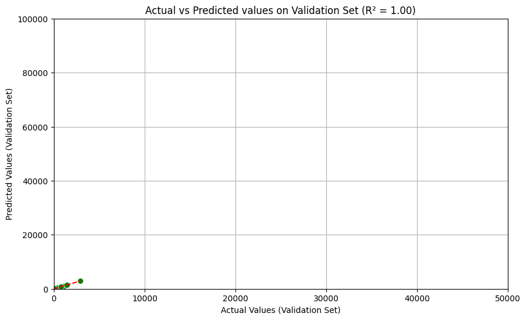

```python
import seaborn as sns
import matplotlib.pyplot as plt
from sklearn.metrics import r2_score
import numpy as np

# Calculate R² (coefficient of determination) for the validation set
r2_valdata = r2_score(y_validate, y_validate_pred)

# Create a scatter plot using Seaborn for the validation set
plt.figure(figsize=(10, 6))

# Scatter plot for Actual vs Predicted values on validation set
sns.scatterplot(x=y_validate, y=y_validate_pred, color='green', s=50)

# Plot a line for perfect predictions (where actual = predicted)
plt.plot([y_validate.min(), y_validate.max()], [y_validate.min(), y_validate.max()], color='red', linestyle='--')

# Update layout: titles, labels, axis limits
plt.title(f'Actual vs Predicted values on Validation Set (R² = {r2_valdata:.2f})')
plt.xlabel('Actual Values (Validation Set)')
plt.ylabel('Predicted Values (Validation Set)')
plt.xlim(0, 50000)  # Set x-axis limits
plt.ylim(0, 100000) # Set y-axis limits

plt.grid(True)
plt.show()
```

# 15. Linear regression – predict the test data based on the model you build in step 14, store that into a datframe called df_unseen. ( Code provide for help)

```python
# Make predictions on the unseen test data
print("\nPredicted worldwide gross values for unseen test data:")
print(y_test_pred)
# Make predictions on the unseen test data
print("\nPredicted worldwide gross values for unseen test data:")
print(y_test_pred)
```

```
Predicted worldwide gross values for unseen test data:
[ 833.60703028   95.09597311  366.75171571  442.40273532 1483.25143553
  629.35413368  518.5515592  1024.96460098  349.55744209  356.6936037
  311.97370903  891.78422891  666.27639245   79.82272883  602.90597803
  283.00121774  -76.53811854 1130.31606519  484.83380969  759.39794539
  692.69365598  369.74514837  471.02250412  815.9862385  1215.60485004
  245.58235558  939.56913976  474.18659698  259.02043892 1026.8564287
   76.80727524  653.5112424   707.98778419  653.59506355  527.14544198
  484.47666849  183.72367887  454.66952927  361.03853977  622.04658121
  427.03667805  350.9131596   386.51199243   29.45676427  109.03693122
  335.49595819  807.5656192   933.81147742  353.20063365  521.29881377
 1153.12320178  372.48764603  352.78964621  588.55033676  434.4715749
  314.5294862   586.14866634  758.48237644  770.07765897  532.77185015
  325.16167355  474.89027183  961.35226053  335.30504876  323.01315825
  754.26989983  224.43548823  378.97227946 1041.33676961  497.12665222
  432.71033847 1663.90224589  555.55696439  464.53447288  323.03612652
  754.13323155  328.04074784  384.07164195  710.90664446  383.89425732
   17.44919635   86.88073428  744.69429733  333.77142505  790.83058961
   64.31946187  450.19767855   56.9472352   314.02877447  352.29374014
  138.66566197  334.30664286  567.66361202  318.38809151  458.48779711
  528.34319614  365.08146073 1071.4783076    55.02220133   69.86049163
  469.21818762  104.75298173  488.45865911  873.06092677  324.17634126
  419.57747126  358.61379623  856.22879635 1126.75790729  795.8172831
  465.59510045  523.29251415  747.64886389]

Predicted worldwide gross values for unseen test data:
[ 833.60703028   95.09597311  366.75171571  442.40273532 1483.25143553
  629.35413368  518.5515592  1024.96460098  349.55744209  356.6936037
  311.97370903  891.78422891  666.27639245   79.82272883  602.90597803
  283.00121774  -76.53811854 1130.31606519  484.83380969  759.39794539
  692.69365598  369.74514837  471.02250412  815.9862385  1215.60485004
  245.58235558  939.56913976  474.18659698  259.02043892 1026.8564287
   76.80727524  653.5112424   707.98778419  653.59506355  527.14544198
  484.47666849  183.72367887  454.66952927  361.03853977  622.04658121
  427.03667805  350.9131596   386.51199243   29.45676427  109.03693122
  335.49595819  807.5656192   933.81147742  353.20063365  521.29881377
 1153.12320178  372.48764603  352.78964621  588.55033676  434.4715749
  314.5294862   586.14866634  758.48237644  770.07765897  532.77185015
  325.16167355  474.89027183  961.35226053  335.30504876  323.01315825
  754.26989983  224.43548823  378.97227946 1041.33676961  497.12665222
  432.71033847 1663.90224589  555.55696439  464.53447288  323.03612652
  754.13323155  328.04074784  384.07164195  710.90664446  383.89425732
   17.44919635   86.88073428  744.69429733  333.77142505  790.83058961
   64.31946187  450.19767855   56.9472352   314.02877447  352.29374014
  138.66566197  334.30664286  567.66361202  318.38809151  458.48779711
  528.34319614  365.08146073 1071.4783076    55.02220133   69.86049163
  469.21818762  104.75298173  488.45865911  873.06092677  324.17634126
  419.57747126  358.61379623  856.22879635 1126.75790729  795.8172831
  465.59510045  523.29251415  747.64886389]
```

```python
# Create a DataFrame to store the predictions and actual values
df_unseen = pd.DataFrame({
    'Actual_Worldwide_Gross': y_test,      # Actual worldwide gross values
    'Predicted_Worldwide_Gross': y_test_pred # Predicted worldwide gross values from the model
})

# Optionally, you can also include the feature columns from the test set
# df_unseen = pd.concat([X_test.reset_index(drop=True), df_unseen], axis=1)

# Display the first few rows of the new DataFrame
print("\nUnseen data with Actual and Predicted worldwide_gross values:")
print(df_unseen.head())
```

```
Unseen data with Actual and Predicted worldwide_gross values:
     Actual_Worldwide_Gross  Predicted_Worldwide_Gross
520                   836.0                 833.607030
304                    91.0                  95.095973
393                   365.0                 366.751716
17                    443.0                 442.402735
512                  1487.0                1483.251436
```

# 16. Create a scatter plot for Actual vs. Predicted gross --Test Set

```python
df_unseen.sample(5)
```

|  | Actual_Worldwide_Gross | Predicted_Worldwide_Gross |
| --- | --- | --- |
| 304 | 91.0 | 95.095973 |
| 145 | 7.0 | 17.449196 |
| 104 | 353.0 | 352.789646 |
| 354 | 488.0 | 488.458659 |
| 63 | 485.0 | 484.833810 |

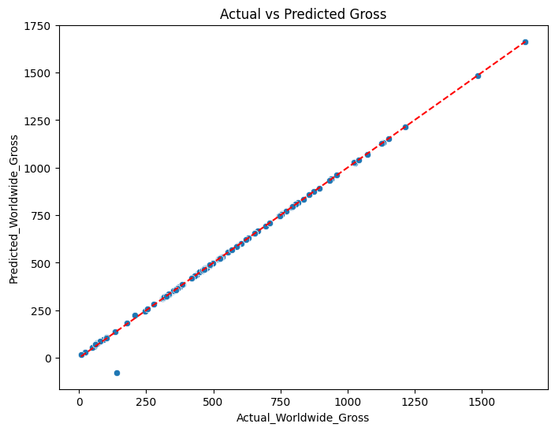

```python
# Create a scatter plot for Actual vs Predicted Worldwide gross values
plt.figure(figsize=(8, 6))
sns.scatterplot(x=df_unseen['Actual_Worldwide_Gross'], y=df_unseen['Predicted_Worldwide_Gross'])

# Add a line for perfect predictions (where actual = predicted)
plt.plot([df_unseen['Actual_Worldwide_Gross'].min(), df_unseen['Actual_Worldwide_Gross'].max()],
       [df_unseen['Actual_Worldwide_Gross'].min(), df_unseen['Actual_Worldwide_Gross'].max()],
       color='red', linestyle='--')

# Add labels and title
plt.xlabel('Actual_Worldwide_Gross')
plt.ylabel('Predicted_Worldwide_Gross')
plt.title('Actual vs Predicted Gross')
plt.show()
```

# 17. Write code to get the intercept and model coefficients, print the intercept

```python
# Get the intercept and coefficients from the model
intercept = model.intercept_  # Intercept of the model
coefficients = model.coef_    # Coefficients of the model

# Print the intercept
print("Intercept:", intercept)
```

```
Intercept: 796.5431299968751
```

# 18. Store the coefficients into a dataframe called coeff_df and print out the dataframe

```python
# Assuming X_train is a pandas DataFrame and you want to map the coefficients to their respective feature names
coeff_df = pd.DataFrame({'Feature': X_train.columns, 'Coefficient': coefficients})
```

```python
coeff_df
```

|  | Feature | Coefficient |
| --- | --- | --- |
| 0 | %_budget_recovered | 3.082482e-02 |
| 1 | X_times_budget_recovered | -3.082921e+00 |
| 2 | budget__(millions) | 1.121520e-02 |
| 3 | domestic_gross_(m) | 9.714607e-01 |
| 4 | domestic_% | -2.342610e+00 |
| 5 | international_gross_(m) | 1.005472e+00 |
| 6 | %_of_gross_from_international | -2.535957e+00 |
| 7 | worldwide_gross | 5.669791e-09 |
| 8 | year | -2.804175e-01 |
| 9 | decade_1980's | 5.761814e+00 |
| 10 | decade_1990's | 8.895404e+00 |
| 11 | decade_2000's | 1.082291e+01 |
| 12 | decade_2010's | 1.377634e+01 |
| 13 | decade_2020's | 1.667995e+01 |
| 14 | horror_horror | 5.436665e+00 |
| 15 | horror_not horror | 7.215640e-02 |

# 19. Print out the feature importance graphs

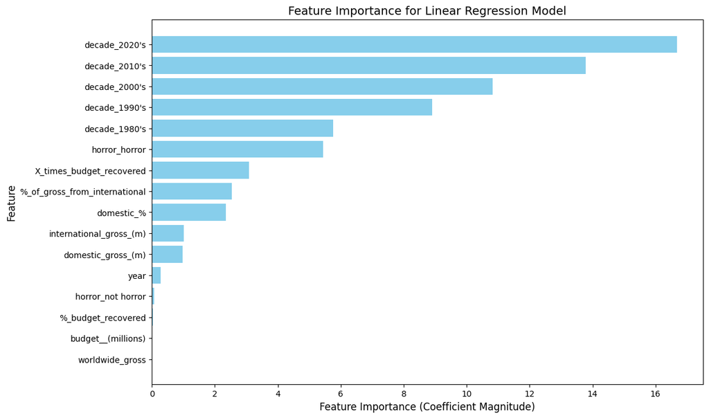

```python
import pandas as pd
import numpy as np
import matplotlib.pyplot as plt

# Assuming you have the trained model and X_train containing feature names
# Get the feature names from the training dataset
feature_names = X_train.columns

# Get the coefficients from the trained linear regression model
coefficients = model.coef_

# Calculate the absolute values of the coefficients to represent feature importance
feature_importance = np.abs(coefficients)

# Create a DataFrame to hold feature names and their corresponding importance
importance_df = pd.DataFrame({'Feature': feature_names, 'Importance': feature_importance})

# Sort the DataFrame by importance (descending order)
importance_df = importance_df.sort_values(by='Importance', ascending=False)

# Plot the feature importance
plt.figure(figsize=(12, 8))  # Increase figure size to make the y-axis larger
plt.barh(importance_df['Feature'], importance_df['Importance'], color='skyblue')
plt.xlabel('Feature Importance (Coefficient Magnitude)', fontsize=12)  # Smaller font size for x-axis label
plt.ylabel('Feature', fontsize=12)  # Smaller font size for y-axis label
plt.xticks(fontsize=10)  # Adjust font size of x-axis ticks
plt.yticks(fontsize=10)  # Adjust font size of y-axis ticks
plt.title('Feature Importance for Linear Regression Model', fontsize=14)  # Adjust title font size
plt.gca().invert_yaxis()  # Invert the y-axis to display the most important feature on top
plt.show()
```

# 20. Linear regression_2 – Drop year, decade and horror and store into a new data frame df_2

# Elimination of Variable

```python
df_2 = df
```

```python
df_2.sample(3)
```

|  | worldwide_gross_(m) | %_budget_recovered | X_times_budget_recovered | budget__(millions) | domestic_gross_(m) | domestic_% | international_gross_(m) | %_of_gross_from_international | worldwide_gross | year | decade | horror |
| --- | --- | --- | --- | --- | --- | --- | --- | --- | --- | --- | --- | --- |
| 355 | 929.0 | 619.0 | 6.2 | 150.0 | 441.0 | 47.5 | 488.0 | 52.5 | 928760770 | 2004 | 2000's | not horror |
| 312 | 1046.0 | 276.0 | 2.8 | 379.0 | 241.0 | 23.0 | 805.0 | 77.0 | 1045713802 | 2011 | 2010's | not horror |
| 457 | 455.0 | 325.0 | 3.2 | 140.0 | 111.0 | 24.4 | 344.0 | 75.6 | 454627263 | 2003 | 2000's | not horror |

```python
# Drop the specified columns from df_2
df_2 = df_2.drop(columns=['year', 'decade', 'horror'], errors='ignore')

# Check the remaining columns in df_2 after dropping
print(df_2.columns)
```

```
Index(['worldwide_gross_(m)', '%_budget_recovered', 'X_times_budget_recovered',
       'budget__(millions)', 'domestic_gross_(m)', 'domestic_%',
       'international_gross_(m)', '%_of_gross_from_international',
       'worldwide_gross'],
      dtype='object')
```

# 21. Prepare data again on the new data frame df_2 - Split the data into train (60%), validation (20%), and test (20%) sets, print the data sets

```python
from sklearn.model_selection import train_test_split

# Define the independent (X) and dependent (y) variables using df_2
X = df_2.drop(columns=['worldwide_gross_(m)']) # Drop the dependent variable from features
y = df_2['worldwide_gross_(m)'] # Define the target variable

# Split the data into train (60%), validation (20%), and test (20%) sets
X_train, X_temp, y_train, y_temp = train_test_split(X, y, test_size=0.4, random_state=42)
X_validate, X_test, y_validate, y_test = train_test_split(X_temp, y_temp, test_size=0.5, random_state=42)

# Print the sizes of the datasets
print(f"Sizes of datasets - Train: {X_train.shape[0]}, Validate: {X_validate.shape[0]}, Test: {X_test.shape[0]}")
```

```
Sizes of datasets - Train: 337, Validate: 112, Test: 113
```

# 22. Linear regression – Perform linear regression, Make predictions on the train, validate and test sets, calculate RMSE and R2 for all three sets

```python
# Fit the multilinear regression model on the training data
model = LinearRegression()
model.fit(X_train, y_train)
```

```
LinearRegression()
```

```python
from sklearn.metrics import mean_squared_error, r2_score

# Make predictions on train, validate, and test sets
y_train_pred = model.predict(X_train)
y_validate_pred = model.predict(X_validate)
y_test_pred = model.predict(X_test)

# Calculate RMSE
train_rmse = mean_squared_error(y_train, y_train_pred, squared=False)
validate_rmse = mean_squared_error(y_validate, y_validate_pred, squared=False)
test_rmse = mean_squared_error(y_test, y_test_pred, squared=False)

# Calculate R²
train_r2 = r2_score(y_train, y_train_pred)
validate_r2 = r2_score(y_validate, y_validate_pred)
test_r2 = r2_score(y_test, y_test_pred)

# Print RMSE and R² for each set
print(f"\nTrain RMSE: {train_rmse}")
print(f"Train R²: {train_r2:.2f}")

print(f"\nValidate RMSE: {validate_rmse}")
print(f"Validate R²: {validate_r2:.2f}")

print(f"\nTest RMSE: {test_rmse}")
print(f"Test R²: {test_r2:.2f}")
```

```
Train RMSE: 8.819267122545261
Train R²: 1.00

Validate RMSE: 1.8947133996933188
Validate R²: 1.00

Test RMSE: 20.1293749956424
Test R²: 1.00
```

```python
# Get the intercept and coefficients from the model
intercept = model.intercept_  # Intercept of the model
coefficients = model.coef_    # Coefficients of the model

# Print the intercept
print("Intercept:", intercept)
```

```
Intercept: 244.51294002082778
```

```python
# Assuming X_train is a pandas DataFrame and you want to map the coefficients to their respective feature names
coeff_df2 = pd.DataFrame({'Feature': X_train.columns, 'Coefficient': coefficients})
```

```python
coeff_df2
```

|  | Feature | Coefficient |
| --- | --- | --- |
| 0 | %_budget_recovered | 5.188978e-02 |
| 1 | X_times_budget_recovered | -5.189178e+00 |
| 2 | budget__(millions) | 6.252425e-03 |
| 3 | domestic_gross_(m) | 9.733147e-01 |
| 4 | domestic_% | -2.321538e+00 |
| 5 | international_gross_(m) | 1.008634e+00 |
| 6 | %_of_gross_from_international | -2.516994e+00 |
| 7 | worldwide_gross | 2.742735e-09 |

# 23. Print out the feature importance graph

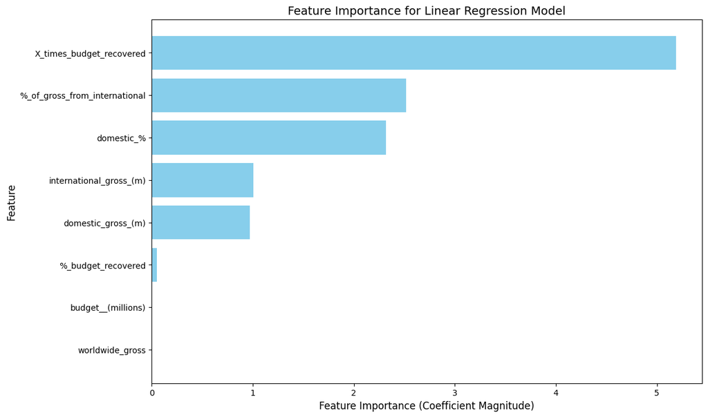

```python
import pandas as pd
import numpy as np
import matplotlib.pyplot as plt

# Assuming you have the trained model and X_train containing feature names
# Get the feature names from the training dataset
feature_names = X_train.columns

# Get the coefficients from the trained linear regression model
coefficients = model.coef_

# Calculate the absolute values of the coefficients to represent feature importance
feature_importance = np.abs(coefficients)

# Create a DataFrame to hold feature names and their corresponding importance
importance_df = pd.DataFrame({'Feature': feature_names, 'Importance': feature_importance})

# Sort the DataFrame by importance (descending order)
importance_df = importance_df.sort_values(by='Importance', ascending=False)

# Plot the feature importance
plt.figure(figsize=(12, 8))  # Increase figure size to make the y-axis larger
plt.barh(importance_df['Feature'], importance_df['Importance'], color='skyblue')
plt.xlabel('Feature Importance (Coefficient Magnitude)', fontsize=12)  # Smaller font size for x-axis label
plt.ylabel('Feature', fontsize=12)  # Smaller font size for y-axis label
plt.xticks(fontsize=10)  # Adjust font size of x-axis ticks
plt.yticks(fontsize=10)  # Adjust font size of y-axis ticks
plt.title('Feature Importance for Linear Regression Model', fontsize=14)  # Adjust title font size
plt.gca().invert_yaxis()  # Invert the y-axis to display the most important feature on top
plt.show()
```

```python
!jupyter nbconvert --to html '/content/drive/My Drive/Assignment2/Assignment_2_Ndumnwere_Ezinne.ipynb'
```

[output not shown]

```python
!apt-get install -y pandoc
```

```python
!apt-get install texlive-xetex texlive-fonts-recommended texlive-plain-generic
```

```python
!jupyter nbconvert --to pdf '/content/drive/My Drive/Assignment1/Assignment_1_Ndumnwere_Ezinne.ipynb'
```